# Submission - SBIR Awards (GSU Analytics)

Ayush

10/2/2021

```r
knitr::opts_chunk$set(message = FALSE, warning = FALSE)
```

[figure not shown]

## Problem Description:

- Understanding the data set with respect to the field and sector of business will give us insights on what the US government believes to yield innovative solutions for the community.
- The analysis will also help us understand the geographical areas involved in creating the said solutions, thereby earning the awards.

## Data and columns used:

- The dataset has been fetched from the ([SBIR](https://www.sbir.gov/sbirsearch/award/all)) website. It contains a total of 188554 rows with columns like the Award Title, Agency giving the award, Award date, Abstract, State in which the company is, Number of Employees etc. We will be selecting the SBIR program only for analysis. Following are the columns used :

  ```
       "Company",

       "Award.Title",

       "Agency",

       "Proposal.Award.Date",

       "Contract.End.Date",

       "Award.Year",

       "Award.Amount",

       "Socially.and.Economically.Disadvantaged",

       "Women.Owned",

       "Number.Employees",

       "State",

       "Zip",

       "Abstract"))
  ```

## Libraries used:

```r
library(topicmodels)
library(quanteda)
library(tidyverse)
library(tidytext)
library(topicdoc)
library(LDAvis)
library(plyr)
library(dplyr)
library(purrr)
library(ggplot2)
library(keyATM)
library(stm)
library(ldatuning)
library(ngram)
library(quanteda.textmodels)
library(quanteda.textstats)
library(quanteda.textplots)
library(textrank)
library(readtext)
library(udpipe)
library(stringr)
library(scales)
library(seededlda)
library(knitr)
#tinytex::install_tinytex()
```

## Importing and Filtering Data:

```r
#f <- file.choose()
df1 = read.csv("award_dataa.csv")
df2 = df1[df1$Program == "SBIR", ] %>%
  select(c("Company",
           "AwardTitle",
           "Agency",
           "ProposalAwardDate",
           "ContractEndDate",
           "AwardYear",
           "AwardAmount",
           "SociallyandEconomicallyDisadvantaged",
           "WomenOwned",
           "NumberEmployees",
           "State",
           "Zip",
           "Abstract"))
df = na.omit(df2)

df$AwardAmount <- gsub(",", "", df$AwardAmount)
df$AwardAmount <- as.numeric(df$AwardAmount)

row.has.na <- apply(df, 1, function(x){any(is.na(x))})
df_final <- df[!row.has.na,]
```

## General Data Insights:

**Following is a graph showing the Agencies and their total amount awarded to companies over the years 1981 to 2021(till now):**

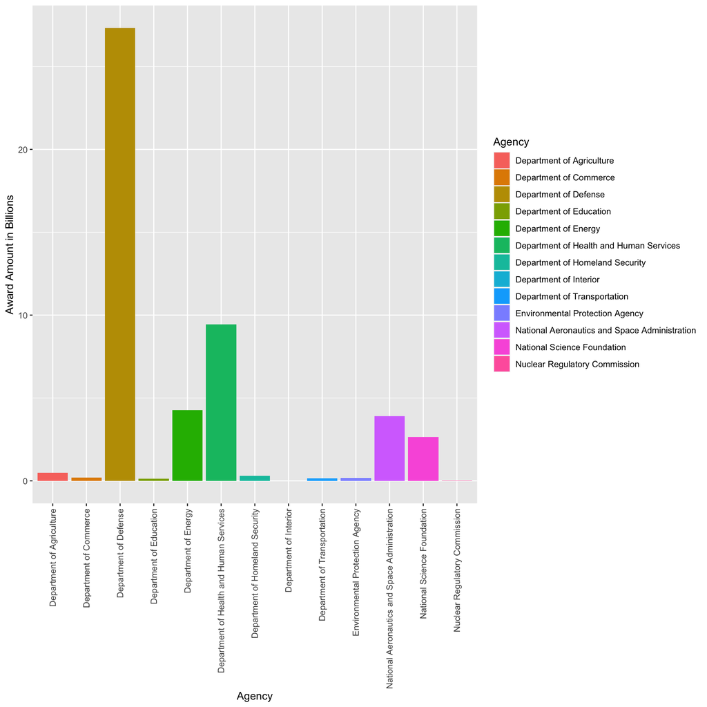

```r
award_amount <- ddply(df_final, c("Agency"), summarize, AwardAmount = sum(AwardAmount))
award_amount = award_amount[-1,]

p = ggplot(award_amount, aes(Agency, AwardAmount/1000000000, fill = Agency)) + geom_col(position = "dodge")+
  theme(axis.text.x = element_text(angle = 90, vjust = 0.5, hjust=1))

p + xlab("Agency")+ ylab("Award Amount in Billions")+ labs(fill = "Agency")
```

## Corpus, Stopwords, Tokenization, DFM and TopFeatures:

```r
df_final$ID <- seq.int(nrow(df_final))
colnames(df_final)[13] <- "text_field"
colnames(df_final)[14] <- "docid_field"

award_corp <- corpus(df_final,
                     text_field = "text_field",
                     docid_field = "docid_field")

mystopwords = c("can", "use", "ii", "new", "using",
                "used", "also", "low", "s", "n", "sbir", "one", "?",
                "two", "demonstrated", "allow","provided", "provides", "results",
                "enable","specific","techniques","large","need","technology","technologies",
                "based","project","developed","developing","provide","provides","approach",
                "many","currently","methods","however","product","phase","develop","design",
                "systems","proposed","development","research","applications","significant",
                "system","due", "study","within", "propose", "available","data","high","low",
                " ", "")

award_toks <- tokens(award_corp, remove_punct = TRUE, remove_numbers = TRUE,
                  remove_symbols = TRUE, remove_url = TRUE, split_hyphens = FALSE)

award_toks <- tokens_remove(  award_toks,
                              pattern = c(stopwords("en"), mystopwords))

award_dfm <- dfm(award_toks, tolower = TRUE) %>%
  dfm_trim(min_termfreq = 40, min_docfreq = 100)

topfeatures(award_dfm, 10)
```

```
## performance       power  commercial        cost     process   materials
##       54825       51638       46859       44493       40137       37915
##     program     control     current        test
##       37263       35815       35418       34225
```

## Keyness plot for ‘Award.Year’ < 1990 vs ‘Award.Year’ >= 1990:

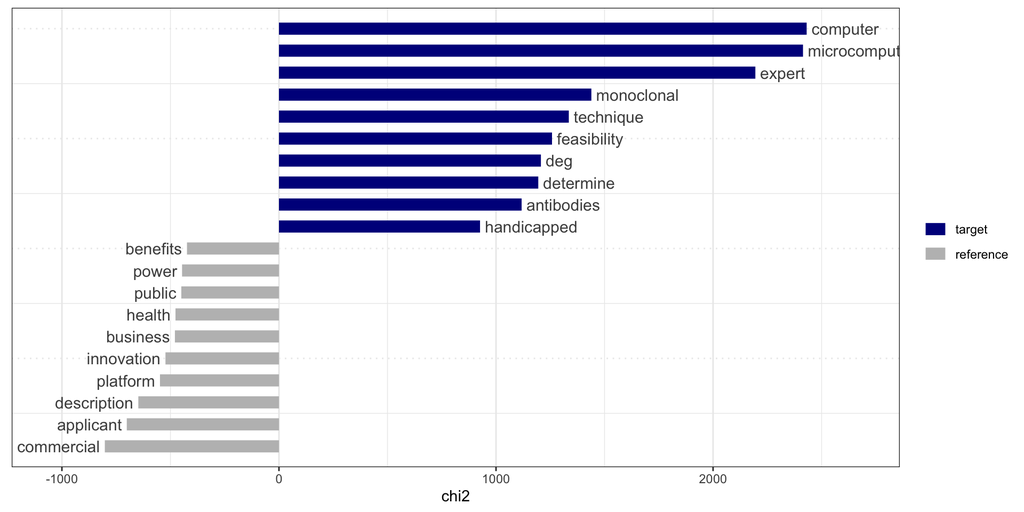

```r
award_tstat_key <- textstat_keyness(award_dfm, target = award_dfm$AwardYear < 1990 )
textplot_keyness(award_tstat_key, n=10, min_count = 10)
```

## Textplot analysis:

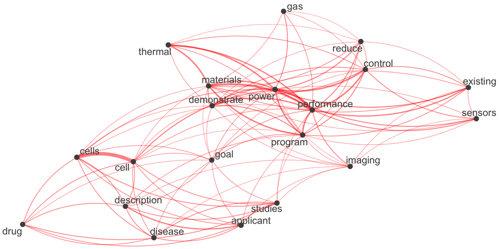

```r
award_dfm_small <- dfm_trim(award_dfm, min_termfreq = 1500)


award_fcmat <- fcm(award_dfm_small)
feat <- names(topfeatures(award_fcmat, 20))
fcmat_select <- fcm_select(award_fcmat, pattern = feat, selection = "keep")

size <- log(colSums(dfm_select(award_fcmat, feat, selection = "keep")))
set.seed(123)
textplot_network(fcmat_select, min_freq = 0.5, edge_size = 1.7, edge_color = "red",
                 vertex_size = size/max(size)*3)
```

## Creating dictionary for *SeededLDA* and *keyATM Base* models:

**We make dictionaries for the following industries:**

> Optics

> Space

> Biotechnology

> Pharmacy

> Automobile

#### To make the dictionary, we use textstat_keyness to find words similar to tokens declared in variable ‘optics’, ‘space’, ‘bio’, ‘pharma’ and ‘auto’. Out of the list returned, we select the top 20 based on the chi2 value.

```r
# imaging
optics <- c("image", "imaging*", "laser", "photons")
toks_inside <- tokens_keep(award_toks, pattern = optics, window = 10)
toks_inside <- tokens_remove(toks_inside, pattern = optics) # remove the keywords
toks_outside <- tokens_remove(award_toks, pattern = optics, window = 10)

dfmat_inside <- dfm(toks_inside)
dfmat_outside <- dfm(toks_outside)

tstat_key_inside <- textstat_keyness(rbind(dfmat_inside, dfmat_outside),
                                     target = seq_len(ndoc(dfmat_inside)))

optics_list <- tstat_key_inside$feature[1:20]

## space

space <- c("space", "aerospace*", "shuttle", "physics", "rocket", "fuel")
toks_inside2 <- tokens_keep(award_toks, pattern = space, window = 10)
toks_inside2 <- tokens_remove(toks_inside2, pattern = space) # remove the keywords
toks_outside2 <- tokens_remove(award_toks, pattern = space, window = 10)

dfmat_inside2 <- dfm(toks_inside2)
dfmat_outside2 <- dfm(toks_outside2)

tstat_key_inside2 <- textstat_keyness(rbind(dfmat_inside2, dfmat_outside2),
                                     target = seq_len(ndoc(dfmat_inside2)))

space_list <- tstat_key_inside2$feature[1:20]


## biotechnology

bio <- c("biotechnology", "biotech*", "CRISPR", "bioengineering", "chromosome", "dna",
         "gene", "gene_editing", "genome")
toks_inside3 <- tokens_keep(award_toks, pattern = bio, window = 10)
toks_inside3 <- tokens_remove(toks_inside3, pattern = bio) # remove the keywords
toks_outside3 <- tokens_remove(award_toks, pattern = bio, window = 10)

dfmat_inside3 <- dfm(toks_inside3)
dfmat_outside3 <- dfm(toks_outside3)

tstat_key_inside3 <- textstat_keyness(rbind(dfmat_inside3, dfmat_outside3),
                                     target = seq_len(ndoc(dfmat_inside3)))

bio_list <- tstat_key_inside3$feature[1:20]

## pharma

pharma <- c("pharmacy", "pharmaceutical*", "medicine", "cancer", "gram", "chemistry",
         "r&d", "drug*", "research")
toks_inside4 <- tokens_keep(award_toks, pattern = pharma, window = 10)
toks_inside4 <- tokens_remove(toks_inside4, pattern = pharma) # remove the keywords
toks_outside4 <- tokens_remove(award_toks, pattern = pharma, window = 10)

dfmat_inside4 <- dfm(toks_inside4)
dfmat_outside4 <- dfm(toks_outside4)

tstat_key_inside4 <- textstat_keyness(rbind(dfmat_inside4, dfmat_outside4),
                                     target = seq_len(ndoc(dfmat_inside4)))
pharma_list <- tstat_key_inside4$feature[1:20]

## automobile

auto <- c("car", "automobile", "fuel", "engineering", "aerodynamic", "machine",
          "airbag*", "pollution", "brake", "gear", "horsepower","transmission")
toks_inside5 <- tokens_keep(award_toks, pattern = auto, window = 10)
toks_inside5 <- tokens_remove(toks_inside5, pattern = auto) # remove the keywords
toks_outside5 <- tokens_remove(award_toks, pattern = auto, window = 10)

dfmat_inside5 <- dfm(toks_inside5)
dfmat_outside5 <- dfm(toks_outside5)

tstat_key_inside5 <- textstat_keyness(rbind(dfmat_inside5, dfmat_outside5),
                                     target = seq_len(ndoc(dfmat_inside5)))

auto_list <- tstat_key_inside5$feature[1:20]
```

## Model 1- Seeded LDA:

**Here we use our created dictionary and get the following 5 topics to from the textmodel_seededlda function:**

```r
award_dict_list = list(optics = optics_list, space = space_list,bio = bio_list,
                       pharma = pharma_list, automobile = auto_list)

award_dict <- quanteda::dictionary(award_dict_list)


award_slda_words <- textmodel_seededlda(award_dfm, dictionary = award_dict)

terms(award_slda_words,20)
```

```
##       optics          space         bio             pharma
##  [1,] "optical"       "power"       "protein"       "treatment"
##  [2,] "fiber"         "energy"      "expression"    "clinical"
##  [3,] "resolution"    "cell"        "genetic"       "patients"
##  [4,] "beam"          "vehicles"    "genes"         "disease"
##  [5,] "infrared"      "engine"      "sequence"      "delivery"
##  [6,] "optics"        "nasa"        "rna"           "compounds"
##  [7,] "spectral"      "solid"       "sequencing"    "screening"
##  [8,] "x-ray"         "nuclear"     "amplification" "therapy"
##  [9,] "images"        "missions"    "sequences"     "therapeutic"
## [10,] "pulse"         "propulsion"  "pcr"           "diseases"
## [11,] "lasers"        "hydrogen"    "vectors"       "discovery"
## [12,] "wavelength"    "combustion"  "hybridization" "tumor"
## [13,] "camera"        "engines"     "genomic"       "breast"
## [14,] "nm"            "fuels"       "mutations"     "therapies"
```

[output cut: 27 more lines]

## Finding the probability of a document belonging to any of the 5 topics created in seededLDA:

```r
get_doc_topic_probs <- function(slda) {
  out <- slda$theta %>%
    as_tibble(rownames ="doc_id")
  return(out)
}
doc_topic <- get_doc_topic_probs(award_slda_words)

a=sum(doc_topic$optics)
b=sum(doc_topic$space)
c=sum(doc_topic$bio)
d=sum(doc_topic$pharma)
e = sum(doc_topic$automobile)

total = a+b+c+d+e

Industries<- c("Optics","Space","Bio.Tech","Pharma","Automobile")
Probability<- c(a/total,b/total,c/total,d/total,e/total)

Doc_prob<- data.frame(Industries,Probability)
kable(Doc_prob, caption = "Topic probabilties for documents")
```

Topic probabilties for documents

| Industries | Probability |
| --- | --- |
| Optics | 0.1825015 |
| Space | 0.2335956 |
| Bio.Tech | 0.2174796 |
| Pharma | 0.1587146 |
| Automobile | 0.2077088 |

## Findings:

**From this model, we can presume that given any award abstract, the probability of it belonging to the *Space Technology* sector is the highest followed by *Biotechnology*, *Automobile*, *Optics*, and *Pharmacy***

## Model 2 - STM:

**Step 1: Finding optimal number of groups:**

We used ldatuning() and the parameters - “CaoJuan2009”, “Arun2010”, “Deveaud2014” to get the desired value of K (number of groups). The model fetched K = 3.

**Step 2: Running the STM model for k = 3**

```r
stm_award_dfm <- quanteda::convert(award_dfm, to = "stm")
out <- prepDocuments(
stm_award_dfm$documents, stm_award_dfm$vocab, stm_award_dfm$meta)

award_tmob_stm <- stm(
out$documents, out$vocab, K=3,
prevalence = ~s(AwardYear),
data=out$meta,
init.type= "Spectral",
max.em.its=30,
seed=123)
```

## Plotting topics from STM:

**1. Summary of data:**

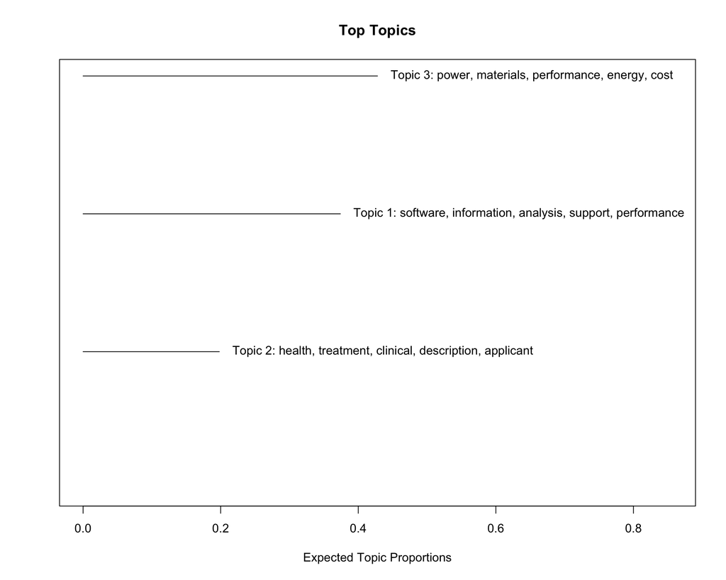

```r
plot(award_tmob_stm, type="summary", n=5)
```

**2. Top 10 keywords in each topic:**

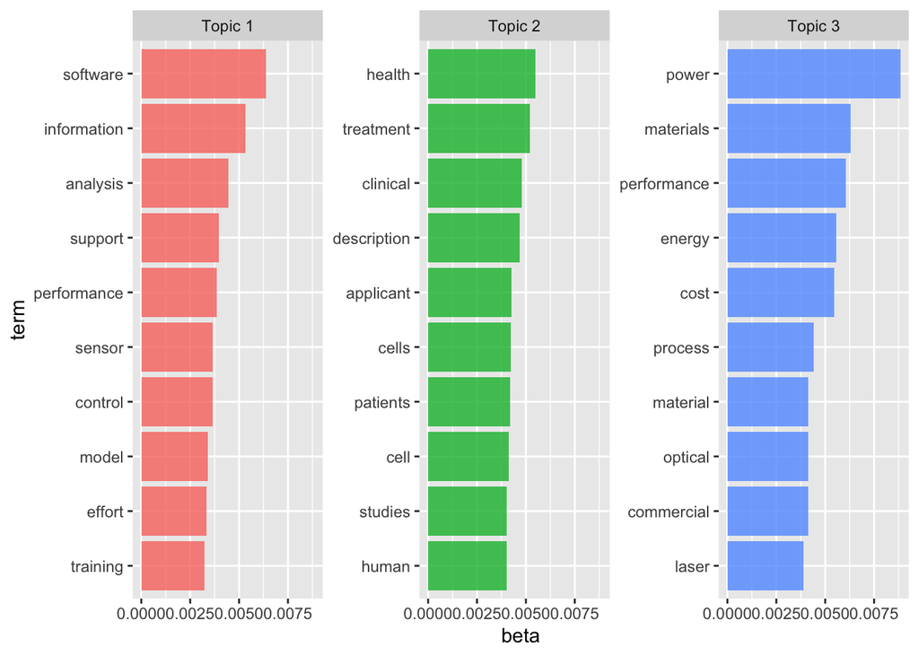

```r
award_tmob_stm_beta <- tidytext::tidy(award_tmob_stm)
award_tmob_stm_beta %>% group_by(topic) %>%
  top_n(10, beta) %>% ungroup() %>%
  mutate(topic = paste0("Topic ", topic),
         term = reorder_within(term, beta, topic)) %>%
  ggplot(aes(term, beta, fill = as.factor(topic))) +
  geom_col(alpha = 0.8, show.legend = FALSE) +
  facet_wrap(~topic, scales="free_y") + coord_flip() + scale_x_reordered()
```

**3. Topic Quality - Exclusivity and Semantic Coherence:**

```r
topicQuality(award_tmob_stm, out$documents)
```

```
## [1] -88.73664 -58.93120 -79.61856
## [1] 8.509404 9.260125 8.832395
```

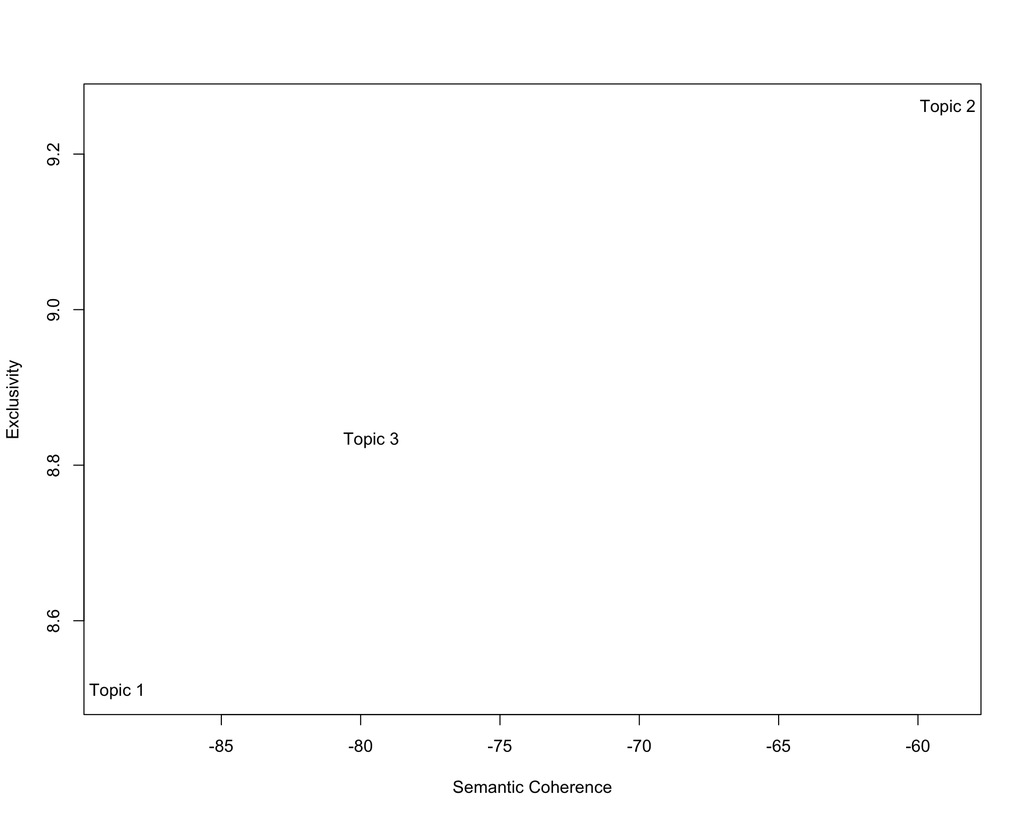

## Findings:

- From the data, dividing the documents in *3* groups is the most optimal to form groups of tokens.
- Topic 1 has low exclusivity and coherence, Topic 3 has moderate exclusivity and coherence and topic 2 has *both* high exclusivity and semantic coherence.

## Model 3 - keyATM Base Model:

**Here we use the dictionary created above and keep 2 no-keyword topics.**

```r
award2_dfm = dfm_subset(award_dfm,ntoken(award_dfm)>0)
keyATM_docs <- keyATM_read(texts = award2_dfm, progress_bar = TRUE)
summary(keyATM_docs)
```

```
## keyATM_docs object of: 138076 documents.
## Length of documents:
##   Avg: 102.169
##   Min: 1
##   Max: 1249
##    SD: 52.074
## Number of unique words: 281173
```

```r
award_tmod_keyatm_base <- keyATM(  docs = keyATM_docs,
                                   no_keyword_topics = 2,
                                   keywords          = award_dict_list,
                                   model             = "base",
                                   options           = list(seed = 123, iterations = 75))
```

#### Top 5 words in our 5 topics and system-generated 2 topics:

```r
top_words(award_tmod_keyatm_base, 5)
```

```
##      1_optics     2_space       3_bio      4_pharma 5_automobile     Other_1
## 1 optical [✓]   power [✓]   detection  clinical [✓]        water    software
## 2       laser   materials protein [✓]  patients [✓]      process information
## 3   power [2]  energy [✓]         dna        health         fuel    training
## 4     imaging performance    cell [2] treatment [✓]          gas    analysis
## 5      sensor     thermal       assay   description         cost       tools
##       Other_2
## 1    software
## 2      sensor
## 3 performance
## 4     control
## 5 information
```

### Insights:

- The keyATM Base model was successfully run with our custom dictionary and 2 no-keyword topics.

## Final takeaways:

> It is clear that the Department of Defense invests the most amount into small businesses.

> Our dictionary suggests that out of the major industries and sectors present, any award has more probability to belong to a company in the *Space Technology* industry